Skip to contents

# 🎨 自定义图表与地图

Source: [`vignettes/articles/zh/customise.Rmd`](https://github.com/Linbojun99/faofishingreport/blob/main/vignettes/articles/zh/customise.Rmd)

```r
fao_settings(lang = "zh")   # 本文所有图表使用中文
```

📦 **数据来源**：[FAO全球捕捞产量](https://www.fao.org/fishery/collection/capture/en)（Global Capture Production）**2026.1.0**版（FAO于2026-03-30发布，1950–2024年），下载地址Capture_2026.1.0.zip，许可证[CC BY 4.0](https://creativecommons.org/licenses/by/4.0/)。用`fao_data_info()`查看你使用的版本和引用格式。

所有图表和地图都遵循少数几项设置，每个R会话中用`fao_settings()`设置一次即可。不带参数运行它可以查看当前设置：

```r
fao_settings()
```

```
#>   lang            en
#>   theme           bw
#>   base_size       12
#>   palette         npg
#>   map_palette     deep-orange
#>   map_center      0
#>   map_projection  longlat
#>   map_land        grey90
#>   map_ocean       NA
#>   grid            FALSE
#>   dpi             600
#>   pptx            FALSE
#>   data_dir        C:/Users/<you>/AppData/Roaming/R/data/R/faofishingreport
#>   online          TRUE
#>   sst             ersst5
#>   silent          FALSE
#>   show_data       TRUE
#>   plot_show       FALSE
#>   font            SimSun
```

`fao_settings(...)`以`名称 = 取值`的形式接收设置，另外还有一个参数`reset`：

| 参数 | 含义 | 默认值 |
| --- | --- | --- |
| `...` | 要修改的设置，形式为`名称 = 取值`（见下表） |  |
| `reset` | 设为`TRUE`时先把所有设置恢复为默认值 | `FALSE` |

各项设置：

| 设置 | 可选值 | 默认值 |
| --- | --- | --- |
| `lang` | 图表语言：`"en"`、`"zh"`、`"both"`；函数自身的`lang`参数优先 | `"en"` |
| `theme` | `"bw"`、`"classic"`、`"minimal"`、`"light"`、`"linedraw"`、`"gray"`、`"dark"`，或任意ggplot2主题对象；地图和饼图保持简洁主题 | `"bw"` |
| `base_size` | 主题的基础字号 | `12` |
| `font` | 图表文字的字体（见字体） | 根据操作系统自动选择 |
| `palette` | 分类配色（国家、物种、分组）：ggsci色板（`"npg"`、`"lancet"`等）、RColorBrewer色板（`"Set1"`等）、基础R色板（`grDevices::palette.pals()`，如`"Okabe-Ito"`；`grDevices::hcl.pals()`，如`"viridis"`），或一组颜色 | `"npg"` |
| `map_palette` | 地图配色：ggsci的Material Design色板（`"deep-orange"`、`"blue"`、`"teal"`等）、RColorBrewer色板（`"YlOrRd"`、`"Blues"`等）、viridis系列（`"viridis"`、`"magma"`、`"plasma"`、`"inferno"`、`"cividis"`、`"mako"`、`"rocket"`、`"turbo"`）… | `"deep-orange"` |
| `map_center` | 地图的中心经度：`0`（经度-180到180，大西洋居中）或`180`（经度0到360，太平洋居中）；也可以写成`"-180-180"`和`"0-360"` | `0` |
| `map_projection` | `"longlat"`、`"robinson"`、`"mollweide"`、`"equal_earth"`、`"winkel_tripel"`、`"mercator"`，或PROJ字符串、EPSG代码（此时不使用`map_center`） | `"longlat"` |
| `map_land` | 地图上无数据国家的颜色 | `"grey90"` |
| `map_ocean` | 地图上海洋的颜色 | `NA`（不填充） |
| `grid` | 背景网格线（地图上为经纬网） | `FALSE` |
| `dpi` | PNG文件的分辨率 | `600` |
| `pptx` | 同时保存可编辑的PowerPoint文件（使用eoffice包） | `FALSE` |
| `data_dir` | 下载的FAO数据所在的文件夹（见💾 FAO数据） | `NULL`：R的用户数据文件夹，见`fao_data_dir()` |
| `online` | 是否允许函数联网查找FishBase的最新版本；设为`FALSE`时离线使用已下载的数据（见🐠 FishBase） | `TRUE` |
| `sst` | `fao_area_sst()`和`mean_temperature_catch()`使用的海表温度数据：`"ersst5"`（内置）、用`download_sst_data()`下载的数据产品（如`"hadisst1"`），或自己的NetCDF文件或文件夹的路径（见🌡️ 海表温度） | `"ersst5"` |
| `silent` | CMSY++函数是否不显示进度条和提示信息；函数自身的`silent`参数优先（见📉 CMSY++） | `FALSE` |
| `show_data` | 函数运行结束时是否在控制台显示结果摘要（分析对象、主要结果表、保存的文件、返回结果包含的部分）；结果以不可见的方式返回 | `TRUE` |
| `plot_show` | 保存图表的同时是否把图画在绘图窗口中（RStudio的Plots窗格）；函数自身的`plot_show`参数优先 | `FALSE` |

`fao_settings(reset = TRUE)`恢复全部默认设置。设置名称或取值有误时会立即报错，并列出可用的选项。每项设置都保存为R选项`faofishingreport.<名称>`，因此也可以用`options()`设置，例如写在`.Rprofile`文件中。`fao_settings()`以不可见的方式返回当前设置组成的列表。

## 🌐 语言

每个分析函数都有`lang`参数；`fao_settings(lang = ...)`会统一修改所有函数的默认语言。`"both"`同时显示中文和英文，例如“百万吨 (Million Tonnes)”和“挪威 Norway”。

```r
fao_settings(lang = "zh")
fishing_area_country(FAO27$area_data, rank_range = 1:6)
```

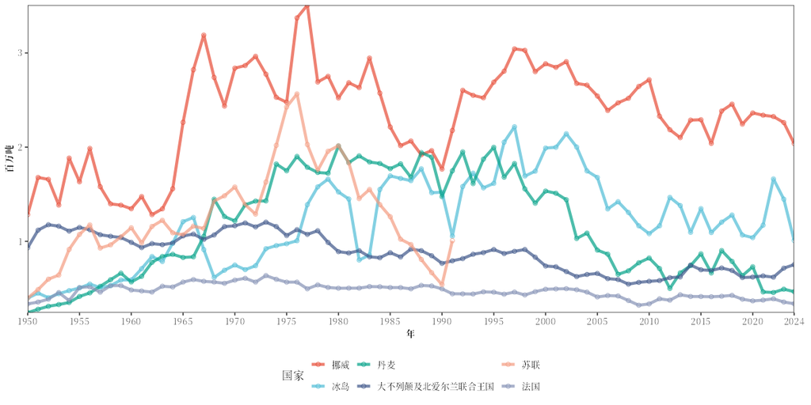

```r
fao_settings(lang = "both")
fishing_area_country(FAO27$area_data, rank_range = 1:6)
```

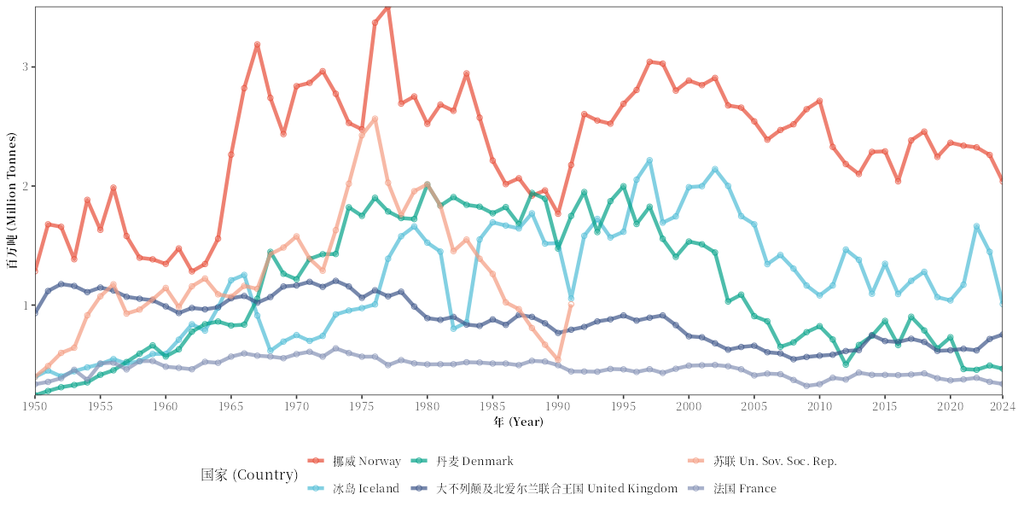

用`fao_settings(lang = "zh")`即可恢复为中文。旧参数`ZH = TRUE`仍然可用，等同于`lang = "zh"`。

## 🖼️ 主题

```r
fao_settings(theme = "classic")
fishing_area_country(FAO27$area_data, rank_range = 1:6)
```

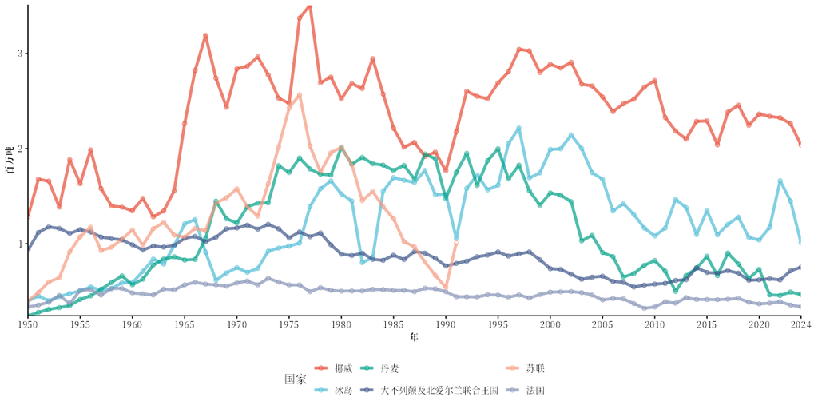

```r
fao_settings(theme = "minimal", base_size = 14)
fishing_area_country(FAO27$area_data, rank_range = 1:6)
```

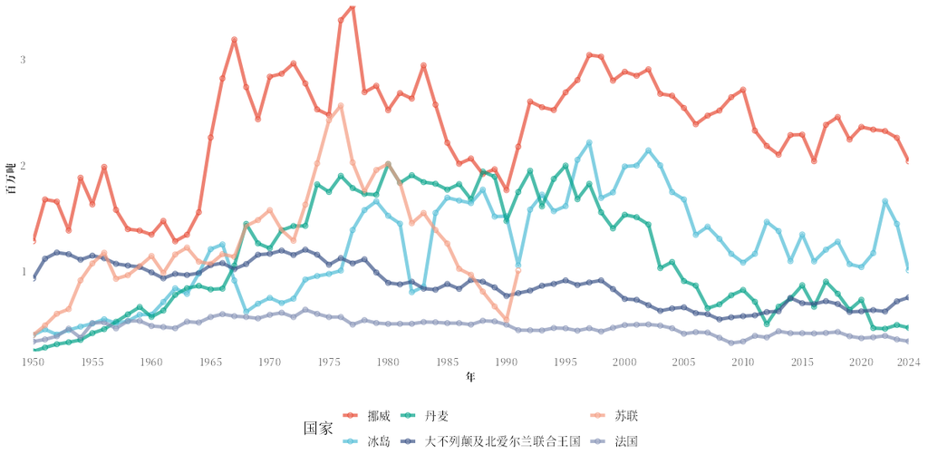

也可以使用任意ggplot2主题，例如`fao_settings(theme = ggplot2::theme_light(base_size = 13))`。

## 🎨 色板

`palette`决定国家、物种和分组的颜色：

```r
fao_settings(theme = "bw", base_size = 12, palette = "lancet")
fishing_area_country(FAO27$area_data, rank_range = 1:6)
```

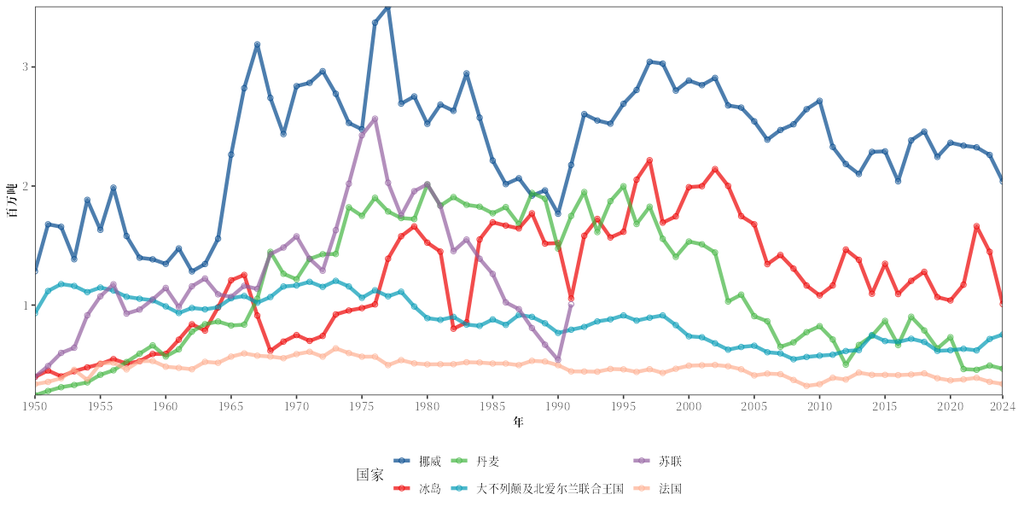

```r
fao_settings(palette = "Okabe-Ito")        # 色盲友好
fishing_area_country(FAO27$area_data, rank_range = 1:6)
```

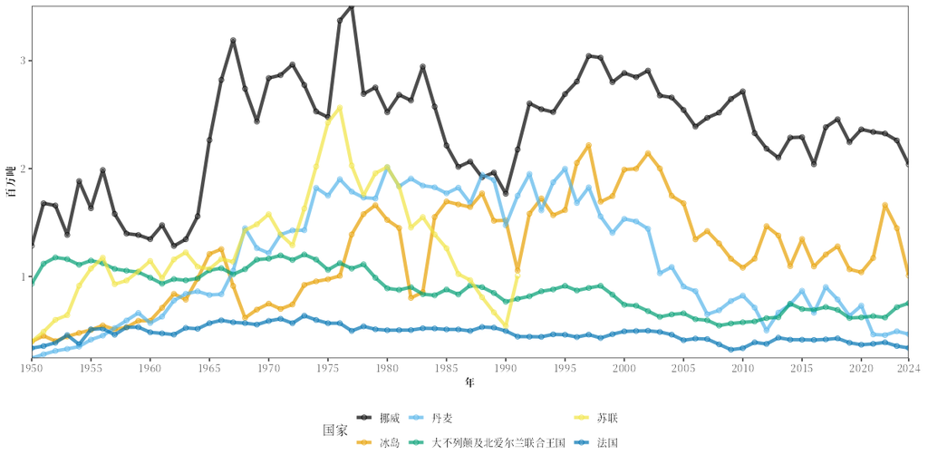

```r
fao_settings(palette = c("#0B2E5B", "#16A6B6", "#F28E2B", "#E15759", "#59A14F", "#B07AA1"))
fishing_area_country(FAO27$area_data, rank_range = 1:6)
fao_settings(palette = "npg")
```

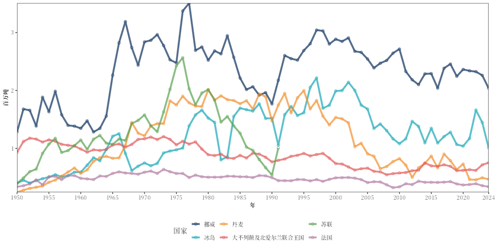

可用的色板包括ggsci包的`"npg"`、`"aaas"`、`"nejm"`、`"lancet"`、`"jama"`、`"jco"`、`"d3"`；RColorBrewer的`"Set1"`、`"Set2"`、`"Dark2"`、`"Paired"`；以及基础R中`grDevices::palette.pals()`（如适合色盲读者的Okabe-Ito色板，Okabe和Ito 2008）和`grDevices::hcl.pals()`（Zeileis等2020）列出的色板。类别数超过色板的颜色数时，会自动插值补足颜色。

## 🗺️ 地图投影

同一张地图（各国在27区的产量）在各种投影下的效果：

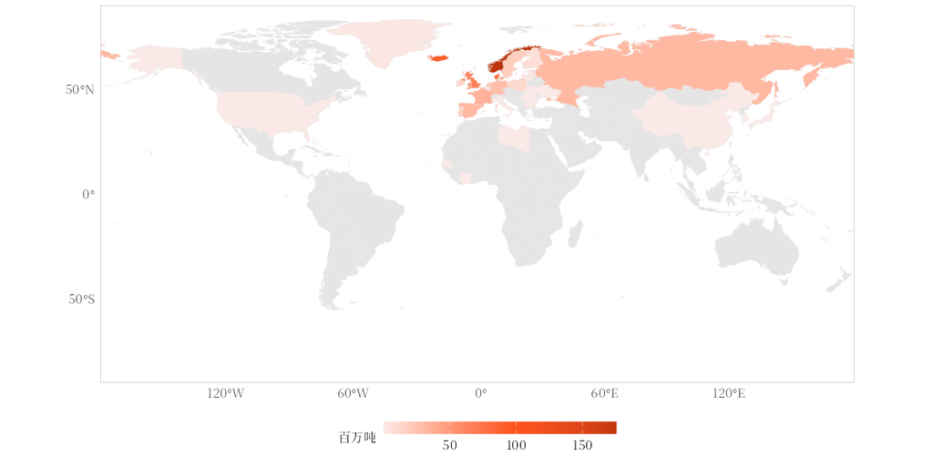

```r
fao_settings(map_projection = "longlat")      # 普通经纬度坐标（默认）
fishing_area_data("Atlantic, Northeast")
```

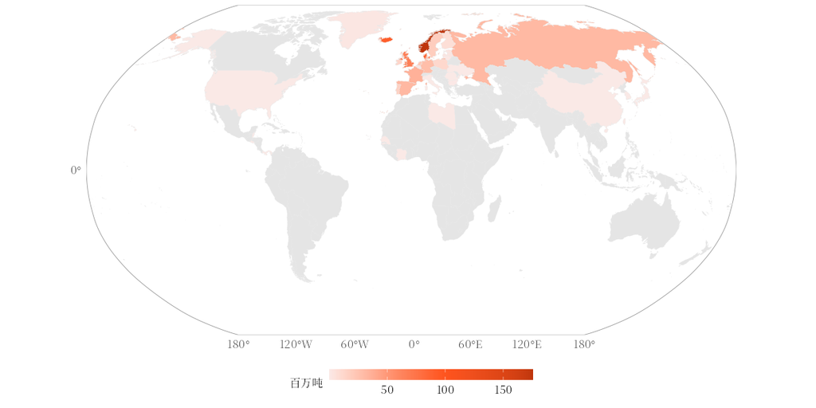

```r
fao_settings(map_projection = "robinson")
fishing_area_data("Atlantic, Northeast")
```

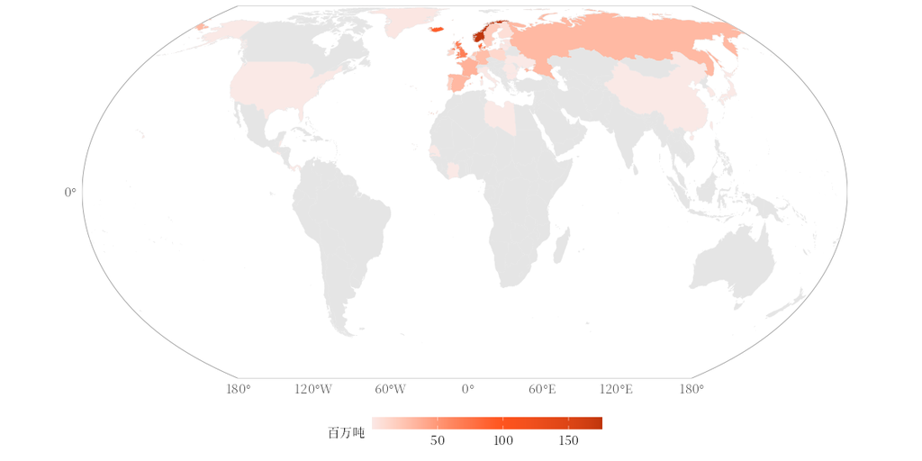

```r
fao_settings(map_projection = "equal_earth")
fishing_area_data("Atlantic, Northeast")
```

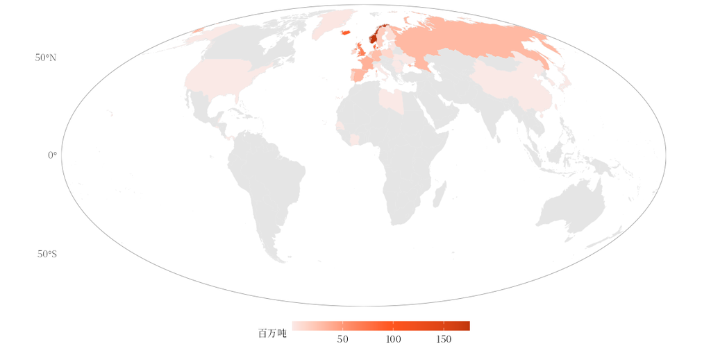

```r
fao_settings(map_projection = "mollweide")
fishing_area_data("Atlantic, Northeast")
```

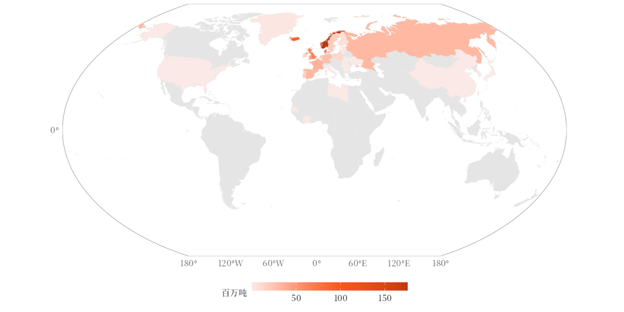

```r
fao_settings(map_projection = "winkel_tripel")
fishing_area_data("Atlantic, Northeast")
```

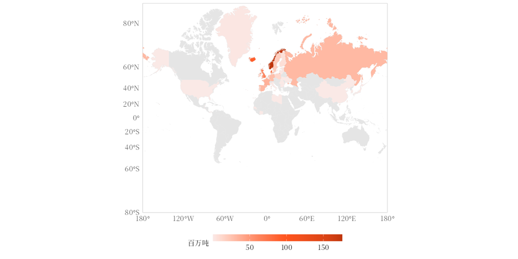

```r
fao_settings(map_projection = "mercator")
fishing_area_data("Atlantic, Northeast")
```

各种命名投影及其对应的PROJ投影（地图由sf绘制，sf使用PROJ库进行投影）：

| `map_projection` | 投影 | PROJ | 特点 |
| --- | --- | --- | --- |
| `"longlat"` | 普通经纬度坐标（等距圆柱投影） | `EPSG:4326`；`map_center = 180`时为`+proj=eqc` | 简单；离赤道越远，面积放大越多 |
| `"robinson"` | Robinson投影（Robinson 1974） | `+proj=robin` | 折中的世界地图投影，既不等积也不等角 |
| `"equal_earth"` | Equal Earth投影（Šavrič等2019） | `+proj=eqearth` | 等积投影，纬线为直线 |
| `"mollweide"` | Mollweide投影（Snyder 1987） | `+proj=moll` | 等积投影，外轮廓为椭圆 |
| `"winkel_tripel"` | Winkel tripel投影 | `+proj=wintri` | 折中的世界地图投影，总体变形较小 |
| `"mercator"` | Mercator投影（Snyder 1987） | `+proj=merc` | 等角投影；越靠近两极面积放大越多，截取南纬80°至北纬84° |

其他投影可以用PROJ字符串或EPSG代码指定，例如`fao_settings(map_projection = "+proj=natearth")`或`"EPSG:3857"`。

## 🌏 太平洋居中地图

`map_center = 180`显示经度0到360，太平洋位于地图中央。数据中在日期变更线处被切开的渔区和国家（如太平洋各渔区、俄罗斯）会重新拼合在一起：

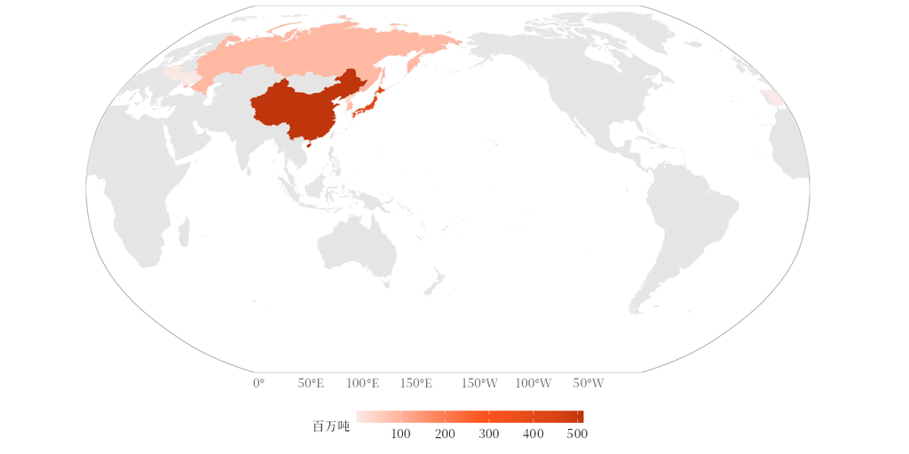

```r
fao_settings(map_projection = "robinson", map_center = 180)
fishing_area_data("Pacific, Northwest")
```

渔区地图中的陆地不绘制国界，所分析的国家以红色显示：

```r
country_analysis("Norway")
```

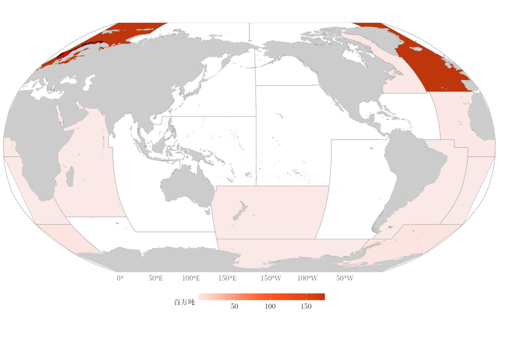

国家轮廓来自Natural Earth的1:50m地图单元，通过ISO 3代码与FAO国家匹配；渔区边界来自FAO主要渔区图层，并为世界地图做了简化。

## 🖌️ 地图配色

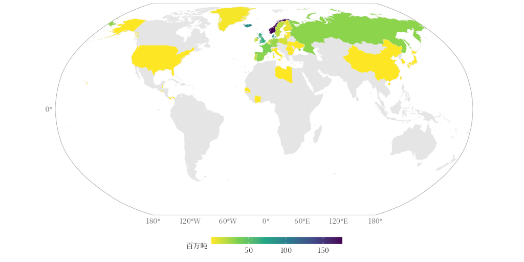

```r
fao_settings(map_projection = "robinson", map_center = 0, map_palette = "viridis")
fishing_area_data("Atlantic, Northeast")
```

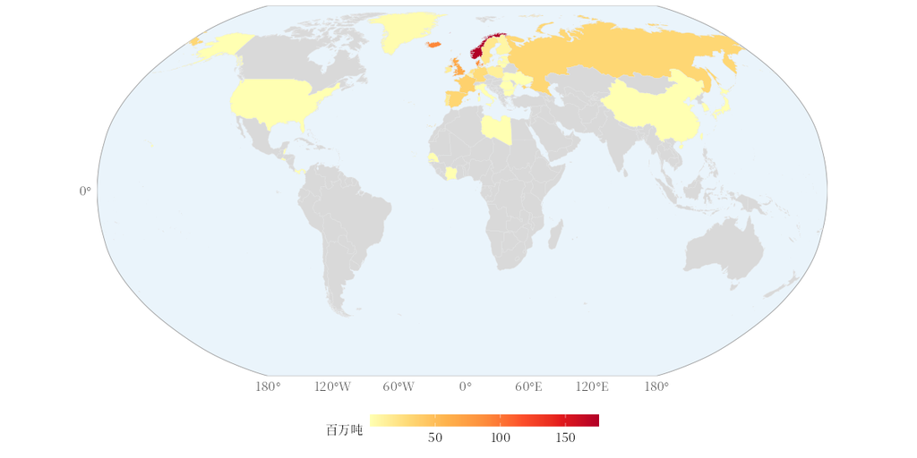

```r
fao_settings(map_palette = "YlOrRd", map_land = "grey85", map_ocean = "#EAF4FB")
fishing_area_data("Atlantic, Northeast")
```

`fishing_area_data()`、`species_country()`和`country_analysis()`的`fill_scale`参数可以在单次调用中覆盖`map_palette`。

## 🔤 字体

字体会根据操作系统自动选择，以保证中文正常显示：Windows上为SimSun，macOS上为Songti SC，Linux上为Noto Serif CJK SC；如果这些字体不可用，则选用系统中已安装的下一个中文字体（都没有时为`"sans"`）。可以这样修改字体：

```r
fao_font()                            # 查看当前字体
fao_settings(font = "Microsoft YaHei")
```

`fao_font()`只有一个参数：

| 参数 | 含义 | 默认值 |
| --- | --- | --- |
| `family` | 此后使用的字体，如`"Microsoft YaHei"`；为`NULL`时只返回当前字体 | `NULL` |

函数返回字体名称。`fao_settings(font = ...)`、`fao_font(...)`和`options(faofishingreport.font = ...)`的效果相同。各系统依次尝试的字体：

| 系统 | 字体（按顺序） |
| --- | --- |
| Windows | SimSun、NSimSun、Microsoft YaHei、SimHei、DengXian、KaiTi |
| macOS | Songti SC、STSong、PingFang SC、Heiti SC、Hiragino Sans GB、Arial Unicode MS |
| Linux | Noto Serif CJK SC、Noto Sans CJK SC、Source Han Serif SC、Source Han Sans SC、WenQuanYi Zen Hei、WenQuanYi Micro Hei、AR PL UMing CN |

已安装的字体由systemfonts包列出。PNG文件由ragg包绘制，它可以按名称找到任何已安装的字体；PowerPoint文件使用相同的字体名称。

## 📐 网格线、分辨率和PowerPoint

```r
fao_settings(grid = TRUE)
fishing_area_country(FAO27$area_data, rank_range = 1:6)
fao_settings(grid = FALSE)
```

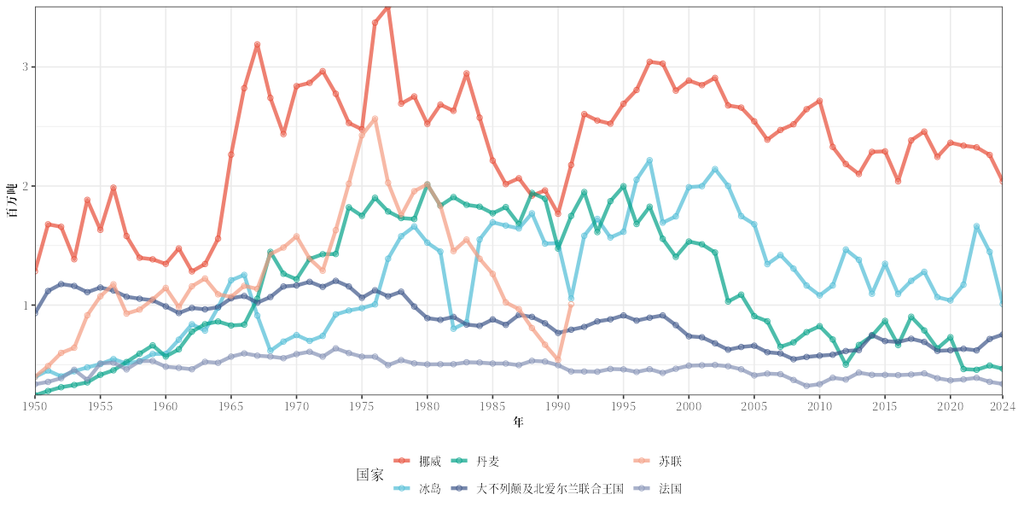

PowerPoint文件由eoffice包生成，它会随faofishingreport一起安装；在macOS上还需要安装[XQuartz](https://www.xquartz.org)。

```r
fao_settings(dpi = 300)      # PNG文件更小
fao_settings(pptx = TRUE)    # 同时在figures/pptx/中保存可编辑的PowerPoint
fishing_area_species(FAO27$area_data, pptx = TRUE)   # 或只对单次调用生效
```

## ⚙️ 各函数的参数

除了上述设置，各分析函数还有各自的参数；其中`lang`、`pptx`和`fill_scale`可以在单次调用中覆盖设置。各篇文章中都有完整的参数表：

| 函数 | 全部参数 |
| --- | --- |
| `fishing_area_data()`、`fishing_area_species()`、`fishing_area_country()`（线宽、点大小、字号和颜色） | 🌊 渔区分析 |
| `species_country()`、`country_species()`、`country_analysis()` | 🐟 物种与国家分析 |
| `check_fao_update()`、`download_fao_data()`、`load_fao_data()`、`fao_data_info()`、`fao_translate()` | 💾 FAO数据 |
| 汇总分析，如`stock_status()`、`peak_trend()` | 📈 类群结构、资源状态与趋势、🔍 数据质量、多样性与船队 |
| `fao_report()` | 📝 一键生成评估报告（Word、LaTeX、PDF） |

## 📝 翻译

国家、物种和渔区的中文名称来自FAO。ISSCAAP类群、主要类群和收入组的中文名称（`inst/extdata/group_names_zh.csv`）以及所有图表标签（`inst/extdata/chart_labels.csv`）都是普通的CSV文件：如需修改措辞，在包源代码中编辑这些文件，然后重新安装本包即可。

## 📖 参考文献

FAO (2024). FAO Major Fishing Areas for Statistical Purposes. In: FAO Fisheries and Aquaculture Division [online]. Licence: CC-BY 4.0. https://www.fao.org/fishery/geonetwork?uuid=ac02a460-da52-11dc-9d70-0017f293bd28 (the area boundaries of the fishing area maps, bundled as `inst/extdata/FAO_AREAS_CWP.shp`)

Guo, K. *eoffice: Export or Graph and Tables to ‘Microsoft’ Office and Import Figures and Tables*. R package. [doi:10.32614/CRAN.package.eoffice](https://doi.org/10.32614/CRAN.package.eoffice)

Harrower, M. and Brewer, C.A. (2003). ColorBrewer.org: an online tool for selecting colour schemes for maps. *The Cartographic Journal* 40(1): 27–37. [doi:10.1179/000870403235002042](https://doi.org/10.1179/000870403235002042)

Massicotte, P. and South, A. *rnaturalearth: World Map Data from Natural Earth*. R package. [doi:10.32614/CRAN.package.rnaturalearth](https://doi.org/10.32614/CRAN.package.rnaturalearth)

Natural Earth. Admin 0 – Details, map units, 1:50m. https://www.naturalearthdata.com/downloads/50m-cultural-vectors/50m-admin-0-details/

Okabe, M. and Ito, K. (2008). Color Universal Design (CUD): how to make figures and presentations that are friendly to colorblind people. https://jfly.uni-koeln.de/color/

Pebesma, E. (2018). Simple features for R: standardized support for spatial vector data. *The R Journal* 10(1): 439–446. [doi:10.32614/RJ-2018-009](https://doi.org/10.32614/RJ-2018-009)

Pedersen, T.L. and Shemanarev, M. *ragg: Graphic Devices Based on AGG*. R package. [doi:10.32614/CRAN.package.ragg](https://doi.org/10.32614/CRAN.package.ragg)

PROJ contributors (2026). *PROJ coordinate transformation software library*. Open Source Geospatial Foundation. https://proj.org/. [doi:10.5281/zenodo.5884394](https://doi.org/10.5281/zenodo.5884394)

Robinson, A.H. (1974). A new map projection: its development and characteristics. *International Yearbook of Cartography* 14: 145–155.

Šavrič, B., Patterson, T. and Jenny, B. (2019). The Equal Earth map projection. *International Journal of Geographical Information Science* 33(3): 454–465. [doi:10.1080/13658816.2018.1504949](https://doi.org/10.1080/13658816.2018.1504949)

Snyder, J.P. (1987). *Map Projections: A Working Manual*. U.S. Geological Survey Professional Paper 1395. Washington, DC: U.S. Government Printing Office. [doi:10.3133/pp1395](https://doi.org/10.3133/pp1395)

Wickham, H. (2016). *ggplot2: Elegant Graphics for Data Analysis*. New York: Springer. [doi:10.1007/978-3-319-24277-4](https://doi.org/10.1007/978-3-319-24277-4)

Xiao, N. *ggsci: Scientific Journal and Sci-Fi Themed Color Palettes for ‘ggplot2’*. R package. [doi:10.32614/CRAN.package.ggsci](https://doi.org/10.32614/CRAN.package.ggsci)

Zeileis, A., Fisher, J.C., Hornik, K., Ihaka, R., McWhite, C.D., Murrell, P., Stauffer, R. and Wilke, C.O. (2020). colorspace: a toolbox for manipulating and assessing colors and palettes. *Journal of Statistical Software* 96(1): 1–49. [doi:10.18637/jss.v096.i01](https://doi.org/10.18637/jss.v096.i01)